# San Juan escapement 2023 (PRELIM)

South Coast StA

Last update: 2024-05-15

# 1 **Sockeye**

Three complete surveys conducted over 2-3 days per survey were conducted for in 2023. They were likely too late for an accurate SK estimate and did not include Fairy Lake where there is the potential for some lake spawners.

## 1.1 Area 20 raw vs expanded counts

Counts are expanded for % population estimated and/or observer efficiency, depending on survey conditions.

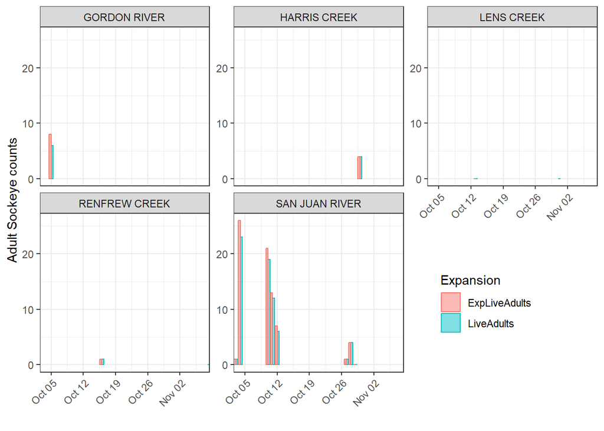

Figure: Raw live Adult Sockeye counts (blue) and expanded for OE (pink).

## 1.2 Counts & environmentals

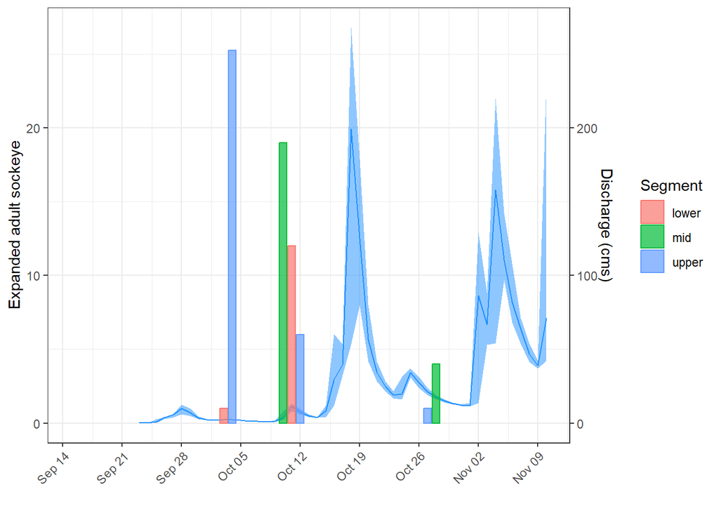

Figure: Sockeye raw counts (live adults) and water levels (blue line) in the San Juan mainstem.

## 1.3 Behaviour & carcasses

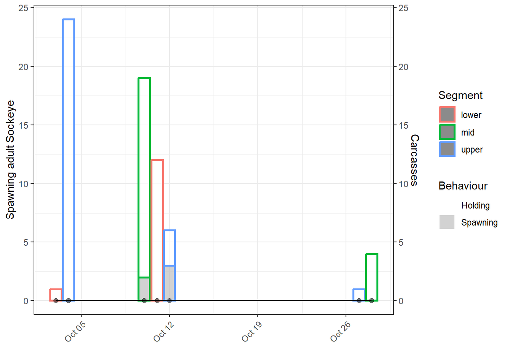

Figure: Raw live adult Sockeye (bars) and carcasses (black line) in the San Juan mainstem. Bar fill colour indicates behaviour (spawning=gray, holding=white) while bar outline colour indicates river segment (lower=pink, mid=green, upper=blue). Note Oct 3/4 “mid” section was covered within upper and lower segments.

## 1.4 Swim & fence counts

No sockeye were passed through the fence in 2023.

## 1.5 Tributaries

Table: Sockeye counts (raw live and dead) for San Juan tributaries (Renfrew, Lens, Harris) and Gordon River in 2023.

| trib_status | system | date | live_adults | dead_adults |
| --- | --- | --- | --- | --- |
| Other Area 20 | Gordon | 2023-10-05 | 6 | 0 |
| San Juan trib | Harris | 2023-10-30 | 4 | 0 |
| San Juan trib | Renfrew | 2023-10-16 | 1 | 0 |

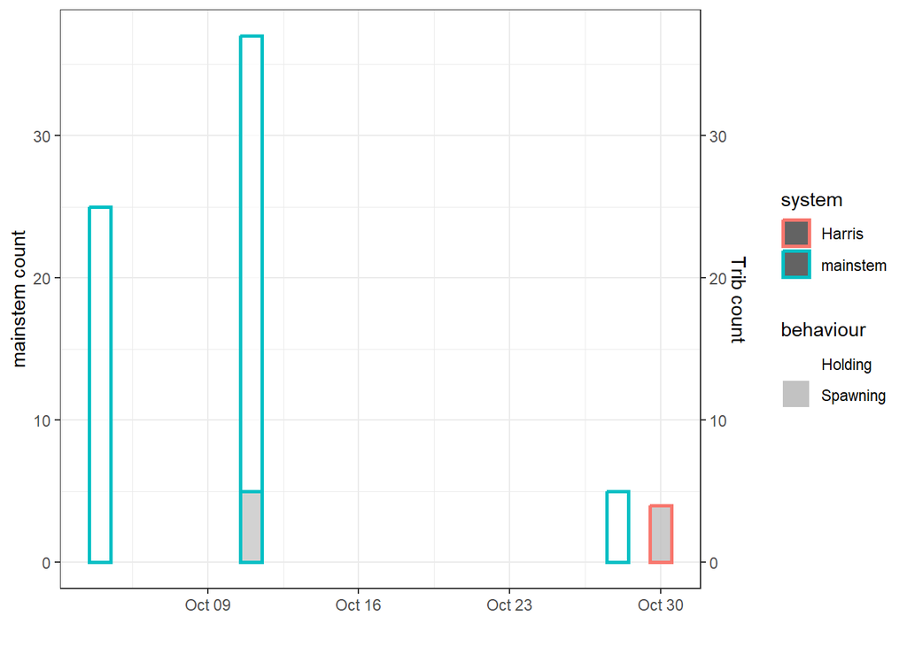

## 1.6 Area 20 preliminary escapement estimates (PL+D)

Table: San Juan raw swim data (raw and expanded live and dead) for Sockeye.

| ShortSpecies | Section_AreaInspected | SDate | WaterTemperature | WaterClarity | LiveAdults | DeadAdults | LiveJacks | DeadJacks | ExpLiveAdults | ExpDeadAdults | ExpLiveJacks | ExpDeadJacks | OverallReliability | EstPctSeen |
| --- | --- | --- | --- | --- | --- | --- | --- | --- | --- | --- | --- | --- | --- | --- |
| SK | GORDON RIVER | 2023-10-05 | 9.5 | 3 - 5 m or to Bottom | 6 | 0 | 0 | NA | 8 | NA | NA | NA | H | 0.9 |
| SK | HARRIS CREEK | 2023-10-30 | 5.0 | 3 - 5 m or to Bottom | 4 | 0 | 0 | NA | 4 | NA | NA | NA | H | 0.9 |
| SK | LENS CREEK | 2023-10-13 | 9.5 | 3 - 5 m or to Bottom | 0 | 0 | 0 | NA | 0 | NA | NA | NA | H | 1.0 |
| SK | LENS CREEK | 2023-10-31 | 3.0 | 3 - 5 m or to Bottom | 0 | 0 | NA | NA | NA | NA | NA | NA | H | NA |
| SK | RENFREW CREEK | 2023-10-16 | 10.0 | 3 - 5 m or to Bottom | 1 | 0 | 0 | NA | 1 | NA | NA | NA | H | 0.9 |
| SK | RENFREW CREEK | 2023-11-08 | 7.0 | 3 - 5 m or to Bottom | 0 | 0 | 0 | NA | NA | NA | NA | NA | H | NA |
| SK | SAN JUAN RIVER | 2023-10-03 | 10.0 | 3 - 5 m or to Bottom | 1 | 0 | 0 | NA | 1 | NA | NA | NA | H | 0.9 |
| SK | SAN JUAN RIVER | 2023-10-04 | 11.5 | 3 - 5 m or to Bottom | 23 | 0 | 1 | NA | 26 | NA | NA | NA | H | 0.9 |
| SK | SAN JUAN RIVER | 2023-10-10 | 9.5 | 3 - 5 m or to Bottom | 19 | 0 | 0 | NA | 21 | NA | NA | NA | H | 0.9 |
| SK | SAN JUAN RIVER | 2023-10-11 | 14.0 | 1 - 3 m | 12 | 0 | 1 | NA | 13 | NA | NA | NA | H | 0.9 |
| SK | SAN JUAN RIVER | 2023-10-12 | 9.5 | 3 - 5 m or to Bottom | 6 | 0 | 0 | NA | 7 | NA | NA | NA | H | 0.9 |
| SK | SAN JUAN RIVER | 2023-10-27 | 6.0 | 3 - 5 m or to Bottom | 1 | 0 | 0 | NA | 1 | NA | NA | NA | H | 0.9 |
| SK | SAN JUAN RIVER | 2023-10-28 | 5.5 | 3 - 5 m or to Bottom | 4 | 0 | 0 | NA | 4 | NA | NA | NA | H | 0.9 |
| SK | SAN JUAN RIVER | 2023-10-29 | 5.0 | 3 - 5 m or to Bottom | 0 | 0 | NA | NA | 0 | NA | NA | NA | H | 1.0 |

Table: Escapement estimates for each system. San Juan mainstem surveys were rolled up based on mid-point date for each of 3 complete survey events, and then the PL+D was selected based on the 3 survey events.

| ShortSpecies | SystemName | AdultRawPLD | AdultExpPLD | JackRawPLD | JackExpPLD | AdultRemovalsReco | JackRemovalsReco | FinalAdultEstimate | FinalJackEstimate |
| --- | --- | --- | --- | --- | --- | --- | --- | --- | --- |
| SK | San Juan River | 37 | 43 | 1 | 1 | 4 | 0 | 39 | 1 |
| SK | Renfrew Creek | 1 | 1 | 0 | 0 | 0 | 0 | 1 | 0 |
| SK | Harris Creek | 4 | 4 | 0 | 0 | 0 | 0 | 4 | 0 |
| SK | Lens Creek | 0 | 0 | 0 | 0 | 0 | 0 | 0 | 0 |
| SK | Gordon River | 6 | 7 | 0 | 0 | 0 | 0 | 7 | 0 |

## 1.7 2023 compared to historical abundance

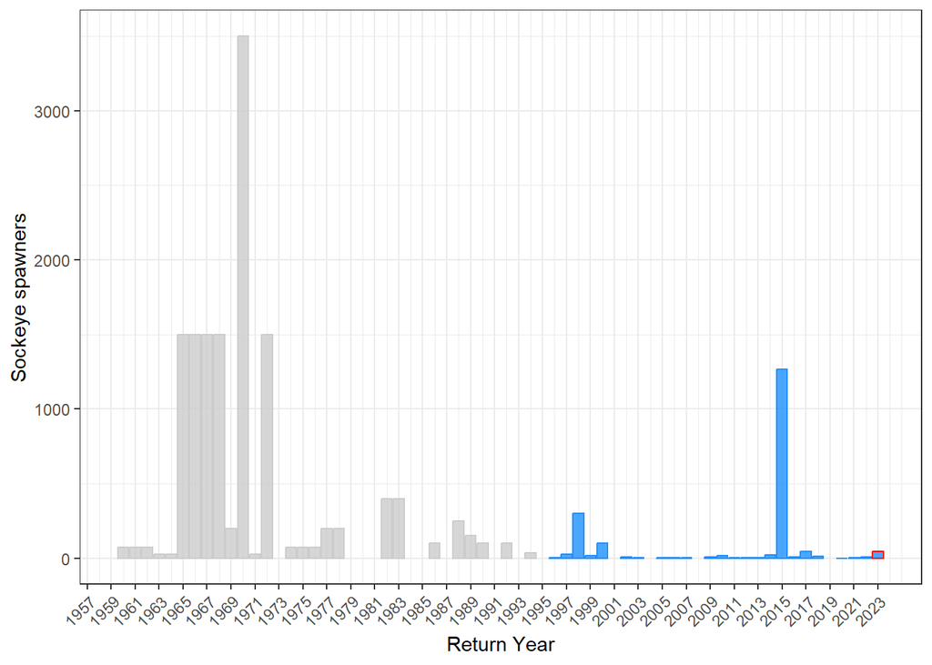

Figure: 2023 preliminary adult Sockeye escapement estimate (red outline) for entire San Juan system (including tributaries) relative to historical adult (blue) and unspecified (gray) escapement estimates. Gaps indicate years without estimates.

# 2 **Coho**

Three complete surveys conducted over 2-3 days per survey were conducted for in 2023. They were likely a little early for an accurate coho estimate.

## 2.1 Area 20 raw vs expanded counts

Counts are expanded for % population estimated and/or observer efficiency, depending on survey conditions. The figure below shows how much raw estimates were expanded for 2023.

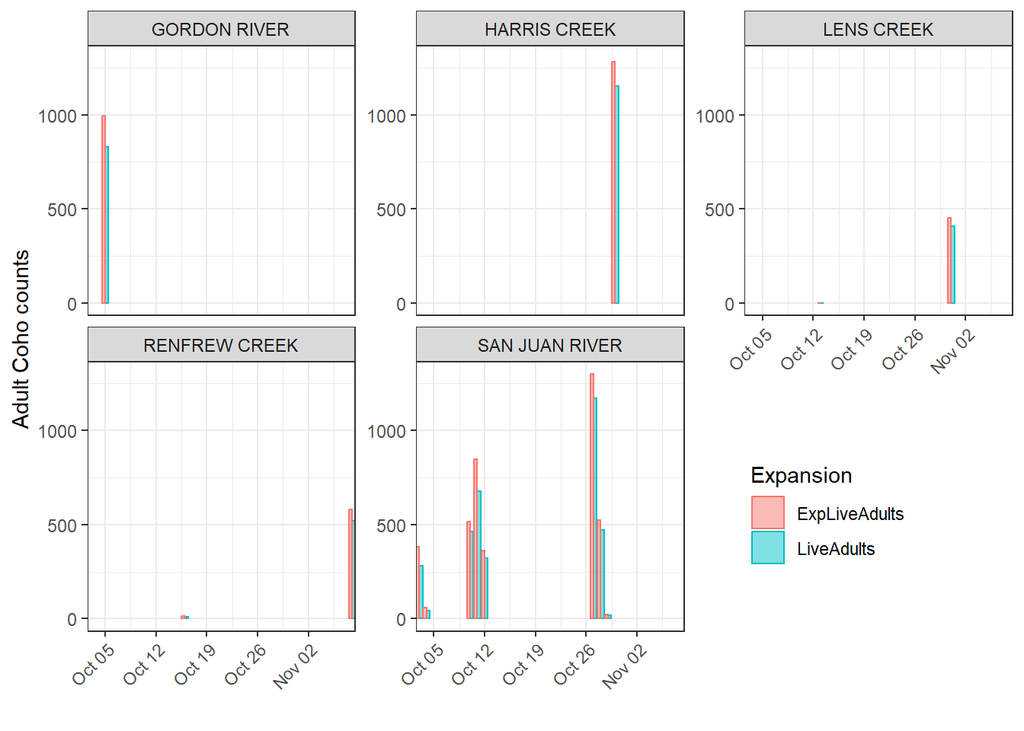

Figure: Raw live Adult Coho counts (blue) and expanded for OE (pink).

## 2.2 Counts & environmentals

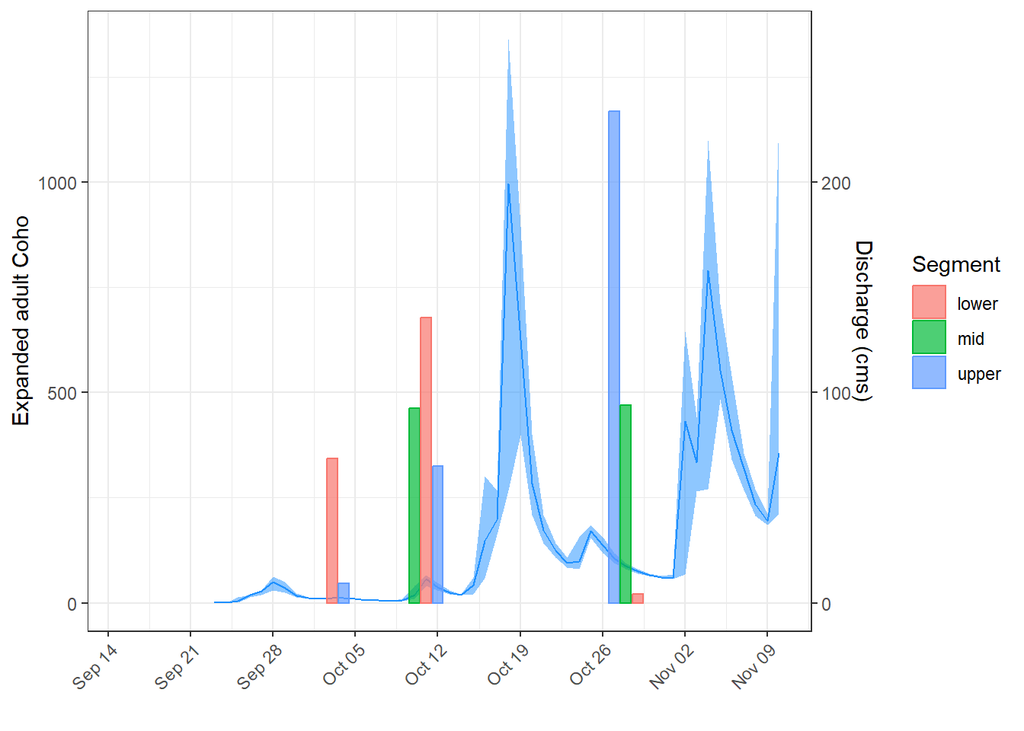

Figure: Coho counts (expanded live adults) and water levels (blue line) in the San Juan mainstem.

## 2.3 Behaviour & carcasses

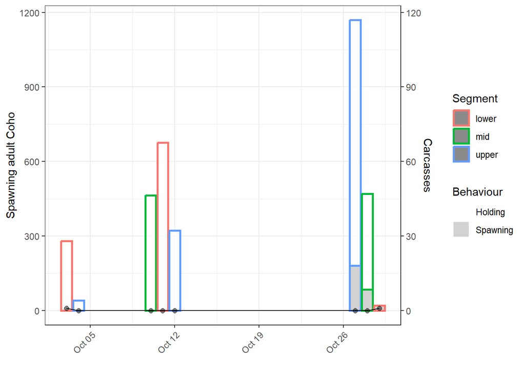

Figure: Expanded live adult Coho (bars) and carcasses (black line) in the San Juan mainstem. Bar fill colur indicates behaviour (spawning=gray, holding=white) while bar outline colour indicates river segment (lower=pink, mid=green, upper=blue). Note Oct 3/4 mid was covered within upper and lower segments.

## 2.4 Swim & fence counts

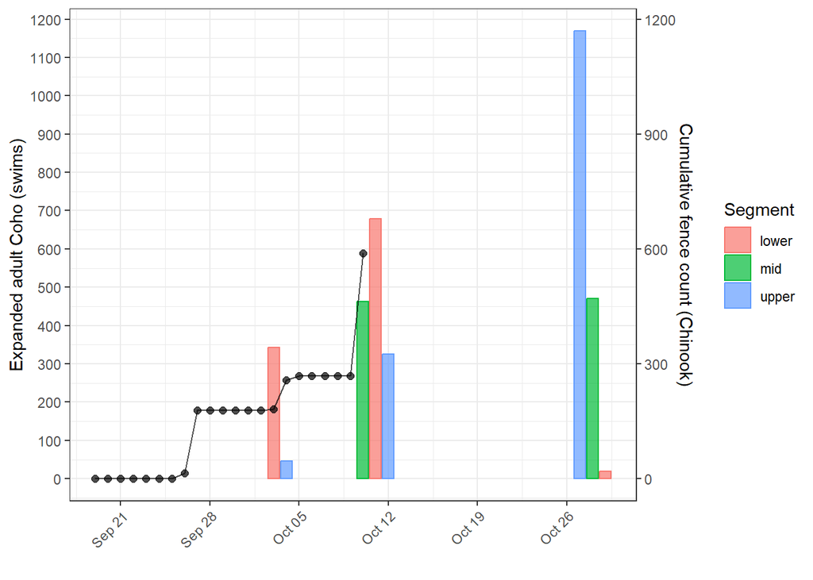

Figure: Coho swim counts (raw adults) in the San Juan mainstem relative to cumulative fence counts (black line).

## 2.5 Tributaries

[output not shown]

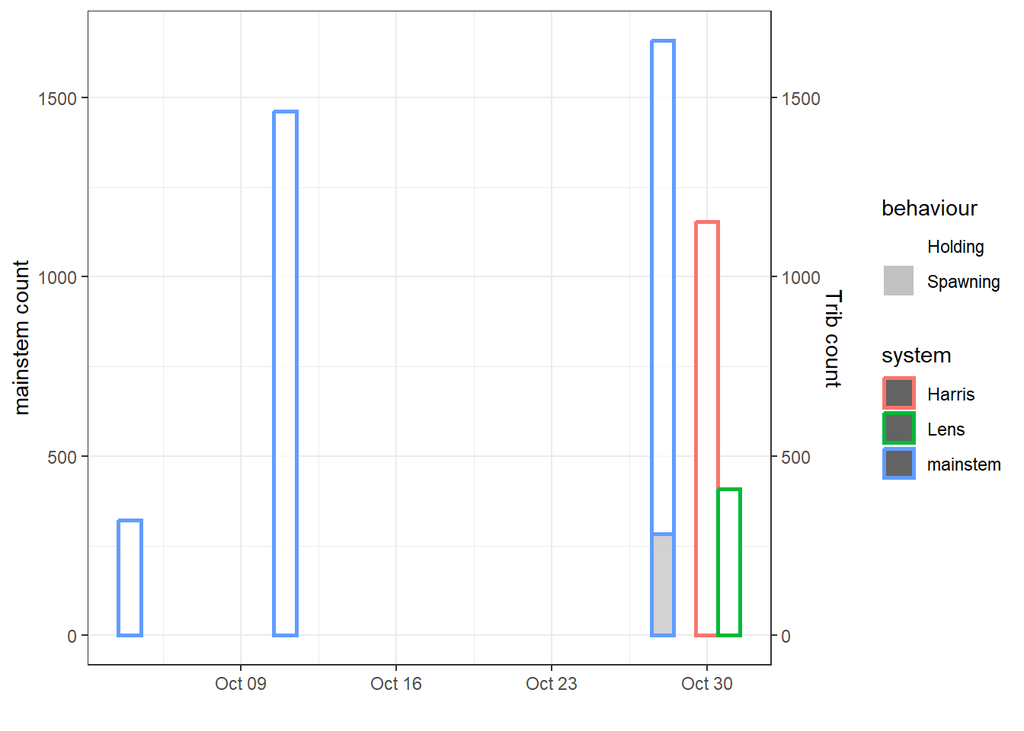

Figure: Mainstem and trib counts for Coho adults (unexpanded). Tribs probably shouldn’t be subtracted from the mainstem as the last 2 mainstem counts were almost identical and spawning had begun ~Oct 27-29. Shortly afterwards it appears most Coho were already in the tribs. Renfrew excluded as it is a Fairy Lake tributary and downstream of most counts.

## 2.6 Area 20 preliminary escapement estimates (PL+D)

Table: Area 20 raw swim data (raw and expanded live and dead) for Coho.

| ShortSpecies | Section_AreaInspected | SDate | WaterTemperature | WaterClarity | LiveAdults | DeadAdults | LiveJacks | DeadJacks | ExpLiveAdults | ExpDeadAdults | ExpLiveJacks | ExpDeadJacks | OverallReliability | EstPctSeen |
| --- | --- | --- | --- | --- | --- | --- | --- | --- | --- | --- | --- | --- | --- | --- |
| CO | GORDON RIVER | 2023-10-05 | 9.5 | 3 - 5 m or to Bottom | 830 | 0 | 112 | NA | 996 | NA | NA | NA | H | 0.9 |
| CO | HARRIS CREEK | 2023-10-30 | 5.0 | 3 - 5 m or to Bottom | 1153 | 0 | 73 | NA | 1281 | NA | NA | NA | H | 0.9 |
| CO | LENS CREEK | 2023-10-13 | 9.5 | 3 - 5 m or to Bottom | 0 | 0 | 0 | NA | 0 | NA | NA | NA | H | 1.0 |
| CO | LENS CREEK | 2023-10-31 | 3.0 | 3 - 5 m or to Bottom | 408 | 0 | 17 | NA | 453 | NA | NA | NA | H | 0.9 |
| CO | RENFREW CREEK | 2023-10-16 | 10.0 | 3 - 5 m or to Bottom | 12 | 0 | 3 | NA | 13 | NA | NA | NA | H | 0.9 |
| CO | RENFREW CREEK | 2023-11-08 | 7.0 | 3 - 5 m or to Bottom | 520 | 0 | 7 | NA | 578 | NA | NA | NA | H | 0.9 |
| CO | SAN JUAN RIVER | 2023-10-03 | 10.0 | 3 - 5 m or to Bottom | 280 | 1 | 0 | NA | 381 | NA | NA | NA | H | 0.9 |
| CO | SAN JUAN RIVER | 2023-10-04 | 11.5 | 3 - 5 m or to Bottom | 41 | 0 | 0 | NA | 58 | NA | NA | NA | M | 0.8 |
| CO | SAN JUAN RIVER | 2023-10-10 | 9.5 | 3 - 5 m or to Bottom | 463 | 0 | 5 | NA | 514 | NA | NA | NA | H | 0.9 |
| CO | SAN JUAN RIVER | 2023-10-11 | 14.0 | 1 - 3 m | 676 | 0 | 16 | NA | 848 | NA | NA | NA | H | 0.8 |
| CO | SAN JUAN RIVER | 2023-10-12 | 9.5 | 3 - 5 m or to Bottom | 322 | 1 | 13 | NA | 361 | NA | NA | NA | H | 0.9 |
| CO | SAN JUAN RIVER | 2023-10-27 | 6.0 | 3 - 5 m or to Bottom | 1169 | 0 | 46 | NA | 1299 | NA | NA | NA | H | 0.9 |
| CO | SAN JUAN RIVER | 2023-10-28 | 5.5 | 3 - 5 m or to Bottom | 470 | 0 | 46 | NA | 522 | NA | NA | NA | H | 0.9 |
| CO | SAN JUAN RIVER | 2023-10-29 | 5.0 | 3 - 5 m or to Bottom | 20 | 1 | 0 | NA | 22 | NA | NA | NA | H | 0.9 |

Table: Escapement estimates for each system. San Juan mainstem surveys were rolled up based on mid-point date for each of 3 complete survey events, and then the PL+D was selected based on the 3 survey events.

| ShortSpecies | SystemName | AdultRawPLD | AdultExpPLD | JackRawPLD | JackExpPLD | AdultRemovalsReco | JackRemovalsReco | FinalAdultEstimate | FinalJackEstimate |
| --- | --- | --- | --- | --- | --- | --- | --- | --- | --- |
| CO | San Juan River | 1660 | 1844 | 92 | 102 | 0 | 0 | 1844 | 102 |
| CO | Renfrew Creek | 520 | 578 | 7 | 8 | 0 | 0 | 578 | 8 |
| CO | Harris Creek | 1153 | 1281 | 73 | 81 | 0 | 0 | 1281 | 81 |
| CO | Lens Creek | 408 | 453 | 17 | 19 | 0 | 0 | 453 | 19 |
| CO | Gordon River | 830 | 922 | 112 | 124 | 0 | 0 | 922 | 124 |

## 2.7 2023 compared to historical run timing and abundance

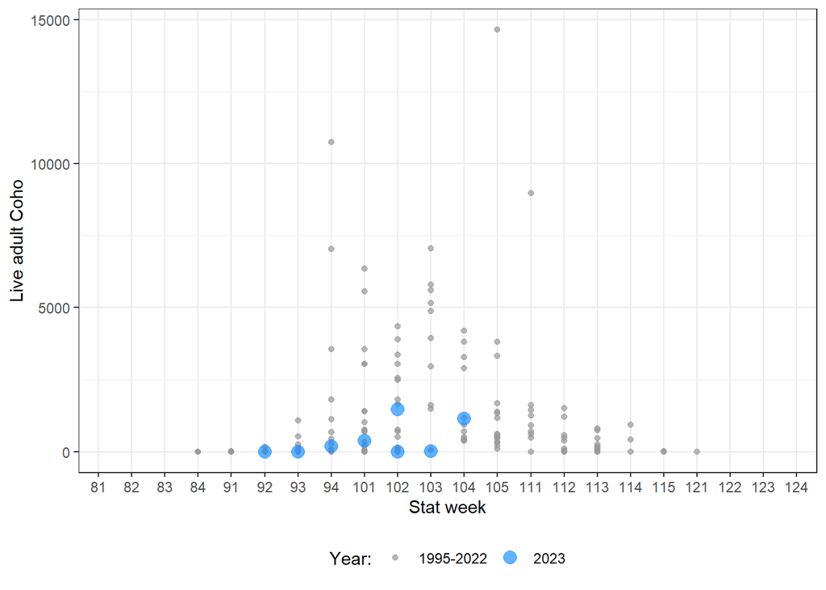

Figure: Raw swim counts (blue) from this year compared to historical raw swim counts. Stat weeks indicate the month (8=August, 12=December) and week of momth (1=first week, 2=2nd week, etc.), e.g., 81=First week of August, 91=First week of September, etc.

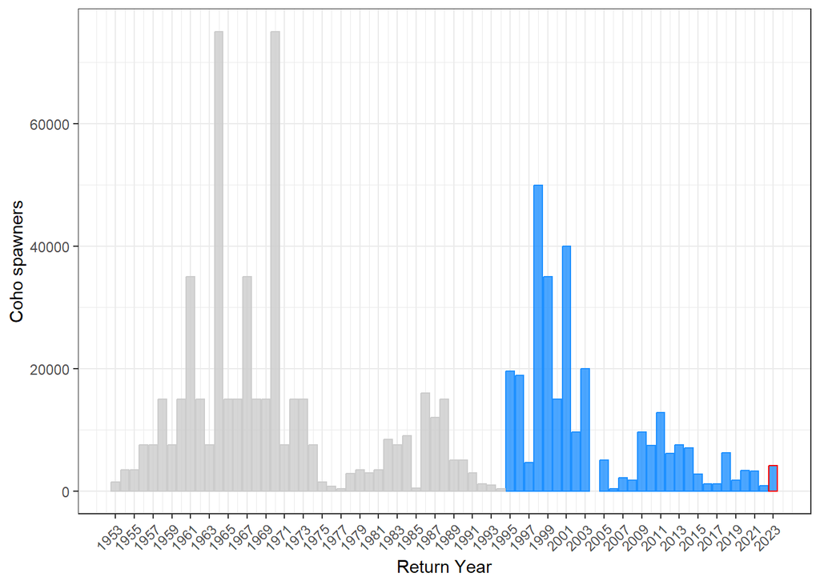

Figure: 2023 preliminary adult Coho escapement estimate (red outline) for entire San Juan system (including tributaries) relative to historical adult (blue) and unspecified (gray) escapement estimates. Gaps indicate years without estimates.

# 3 **Chum**

Three complete surveys conducted over 2-3 days per survey were conducted for in 2023. They were well timed for Chum.

## 3.1 Area 20 raw vs expanded counts

Counts are expanded for % population estimated and/or observer efficiency, depending on survey conditions.

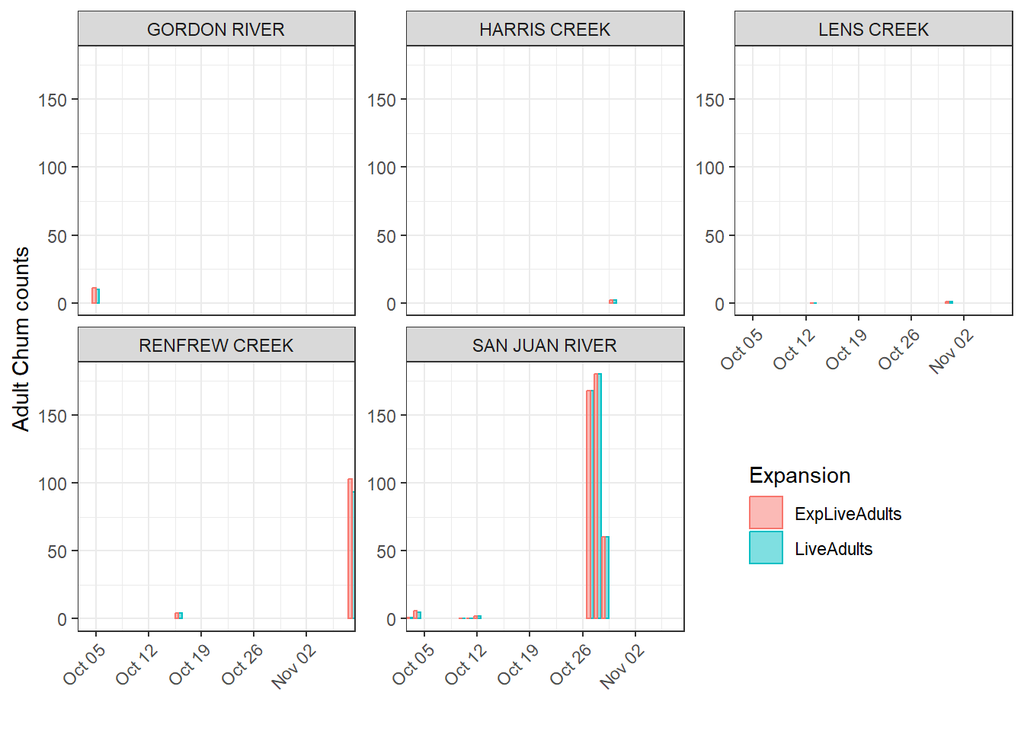

Figure: Raw live Adult Chum counts (blue) and expanded for OE (pink).

## 3.2 Counts & environmentals

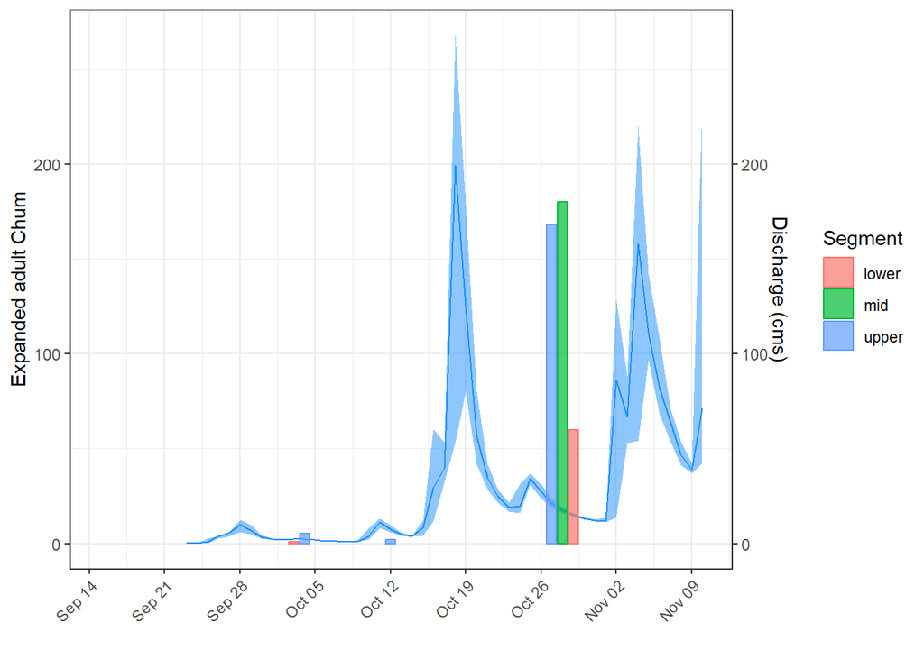

Figure: Chum counts (raw live adults) and water levels (blue line) in the San Juan mainstem.

## 3.3 Behaviour & carcasses

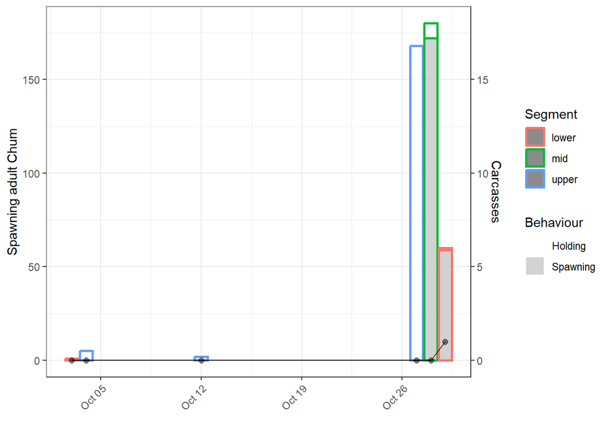

Figure: Raw live adult Chum (bars) and carcasses (black line) in the San Juan mainstem. Bar fill colour indicates behaviour (spawning=gray, holding=white) while bar outline colour indicates river segment (lower=pink, mid=green, upper=blue). Note Oct 3/4 mid was covered within upper and lower segments.

## 3.4 Swim & fence counts

No chum were passed through the fence in 2023.

## 3.5 Tributaries

Table: Chum counts (raw live and dead) for San Juan tributaries (Renfrew, Lens, Harris) and Gordon River in 2023.

| trib_status | system | date | live_adults | dead_adults |
| --- | --- | --- | --- | --- |
| Other Area 20 | Gordon | 2023-10-05 | 10 | 0 |
| San Juan trib | Harris | 2023-10-30 | 2 | 0 |
| San Juan trib | Lens | 2023-10-31 | 1 | 0 |
| San Juan trib | Renfrew | 2023-10-16 | 4 | 0 |
| San Juan trib | Renfrew | 2023-11-08 | 93 | 1 |

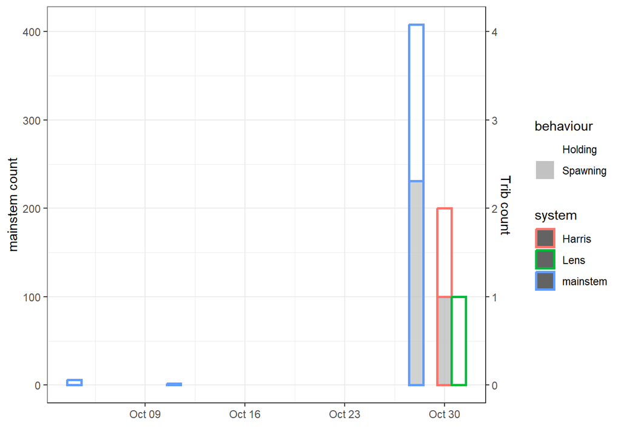

Figure: Mainstem and trib counts for Chum adults (unexpanded). Probably not subtract tribs as spawning was well underway with carcasses accumulating on the last mainstem survey and shortly after there was already tributary spawning. Renfrew Creek not considered for removals as Fairy Lake trib downstream of survey area.

## 3.6 Area 20 preliminary escapement estimate (PL+D)

Table: San Juan swim counts (expanded live and dead) and preliminary escapement estimates for three San Juan surveys in 2023.

| ShortSpecies | Section_AreaInspected | SDate | WaterTemperature | WaterClarity | LiveAdults | DeadAdults | LiveJacks | DeadJacks | ExpLiveAdults | ExpDeadAdults | ExpLiveJacks | ExpDeadJacks | OverallReliability | EstPctSeen |
| --- | --- | --- | --- | --- | --- | --- | --- | --- | --- | --- | --- | --- | --- | --- |
| CM | GORDON RIVER | 2023-10-05 | 9.5 | 3 - 5 m or to Bottom | 10 | 0 | NA | NA | 11 | NA | NA | NA | H | 0.9 |
| CM | HARRIS CREEK | 2023-10-30 | 5.0 | 3 - 5 m or to Bottom | 2 | 0 | NA | NA | 2 | NA | NA | NA | H | 0.9 |
| CM | LENS CREEK | 2023-10-13 | 9.5 | 3 - 5 m or to Bottom | 0 | 0 | NA | NA | 0 | NA | NA | NA | H | 1.0 |
| CM | LENS CREEK | 2023-10-31 | 3.0 | 3 - 5 m or to Bottom | 1 | 0 | NA | NA | 1 | NA | NA | NA | H | 0.9 |
| CM | RENFREW CREEK | 2023-10-16 | 10.0 | 3 - 5 m or to Bottom | 4 | 0 | NA | NA | 4 | NA | NA | NA | H | 0.9 |
| CM | RENFREW CREEK | 2023-11-08 | 7.0 | 3 - 5 m or to Bottom | 93 | 1 | NA | NA | 103 | NA | NA | NA | H | 0.9 |
| CM | SAN JUAN RIVER | 2023-10-03 | 10.0 | 3 - 5 m or to Bottom | 1 | 0 | NA | NA | 1 | NA | NA | NA | H | 0.9 |
| CM | SAN JUAN RIVER | 2023-10-04 | 11.5 | 3 - 5 m or to Bottom | 5 | 0 | NA | NA | 6 | NA | NA | NA | H | 0.9 |
| CM | SAN JUAN RIVER | 2023-10-10 | 9.5 | 3 - 5 m or to Bottom | 0 | 0 | NA | NA | 0 | NA | NA | NA | H | 1.0 |
| CM | SAN JUAN RIVER | 2023-10-11 | 14.0 | 1 - 3 m | 0 | 0 | NA | NA | 0 | NA | NA | NA | H | 1.0 |
| CM | SAN JUAN RIVER | 2023-10-12 | 9.5 | 3 - 5 m or to Bottom | 2 | 0 | NA | NA | 2 | NA | NA | NA | H | 1.0 |
| CM | SAN JUAN RIVER | 2023-10-27 | 6.0 | 3 - 5 m or to Bottom | 168 | 0 | NA | NA | 168 | NA | NA | NA | H | 1.0 |
| CM | SAN JUAN RIVER | 2023-10-28 | 5.5 | 3 - 5 m or to Bottom | 180 | 0 | NA | NA | 180 | NA | NA | NA | H | 1.0 |
| CM | SAN JUAN RIVER | 2023-10-29 | 5.0 | 3 - 5 m or to Bottom | 60 | 1 | NA | NA | 60 | NA | NA | NA | H | 1.0 |

Table: Escapement estimates for each system. San Juan mainstem surveys were rolled up based on mid-point date for each of 3 complete survey events, and then the PL+D was selected based on the 3 survey events.

[output not shown]

## 3.7 2023 compared to historical run timing and abundance

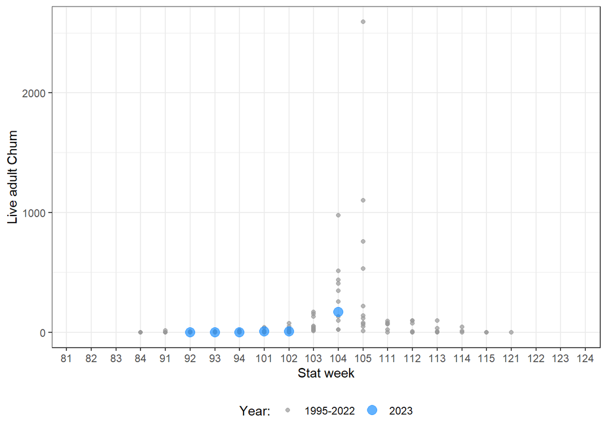

Figure: Raw swim counts (blue) from this year compared to historical raw swim counts. Stat weeks indicate the month (8=August, 12=December) and week of momth (1=first week, 2=2nd week, etc.), e.g., 81=First week of August, 91=First week of September, etc.

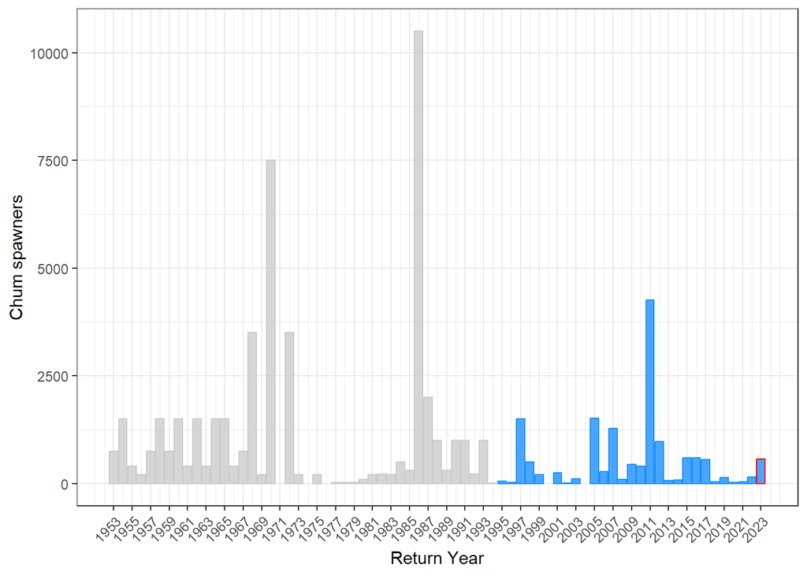

Figure: 2023 preliminary adult Chum escapement estimate (red outline) for entire San Juan system (including tributaries) relative to historical adult (blue) and unspecified (gray) escapement estimates. Gaps indicate years without estimates.

# 4 **Chinook**

Three complete surveys conducted over 2-3 days per survey were conducted for Chinook in 2023.

## 4.1 Area 20 raw vs expanded counts

Counts are expanded for % population estimated and/or observer efficiency, depending on survey conditions.

[figure not shown]

## 4.2 Counts & environmentals

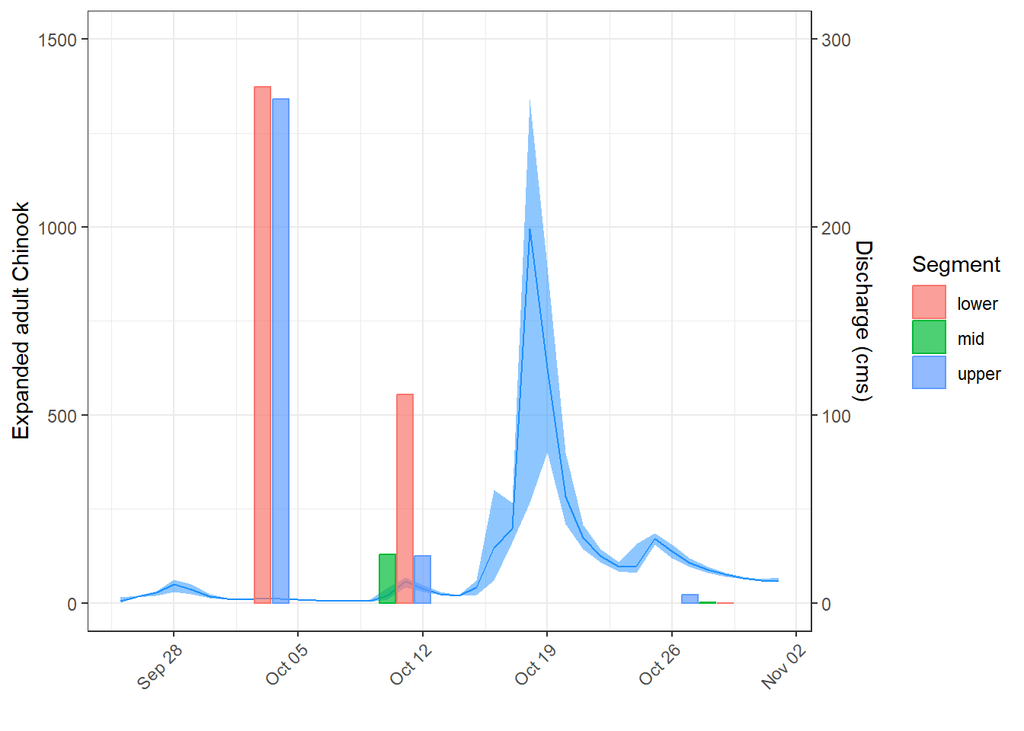

Figure: Chinook counts (expanded live adults) and water levels (blue line) in the San Juan mainstem.

## 4.3 Behaviour & carcasses

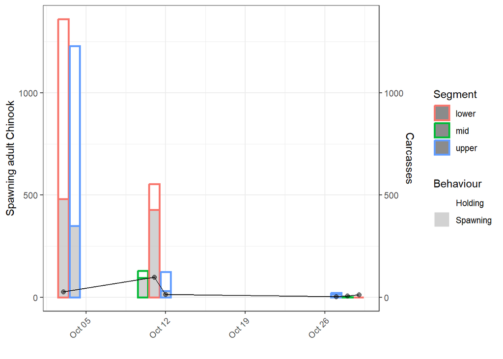

Figure: Expanded live adult Chinook (bars) and carcasses (black line) in the San Juan mainstem. Bar fill colour indicates behaviour (spawning=gray, holding=white) while bar outline colour indicates river segment (lower=pink, mid=green, upper=blue). Note Oct 3/4 mid was covered within upper and lower.

### 4.3.1 Jack to male ratio

The proportion of total chinook that were jacks observed on the swims ranged from 0.1801802% to 3.8371182% (mean = 1.7248228%).

## 4.4 Swim & fence counts

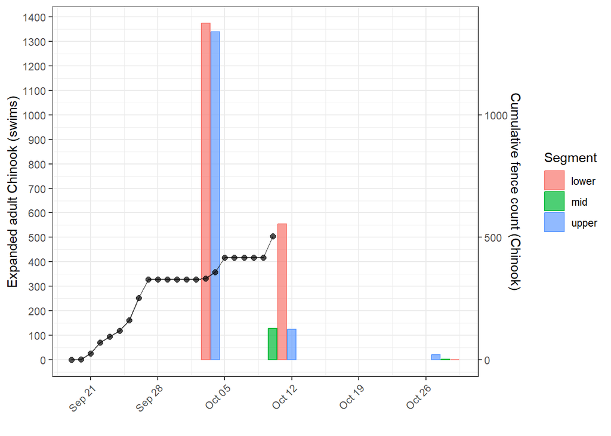

Figure: Chinook swim counts (expanded adults) in the San Juan mainstem relative to cumulative fence counts (black line).

## 4.5 Oct 3/4 surveys

There is some possibility a sizable school of Chinook could have been double counted between the Oct 3 and 4 survey in 2023.

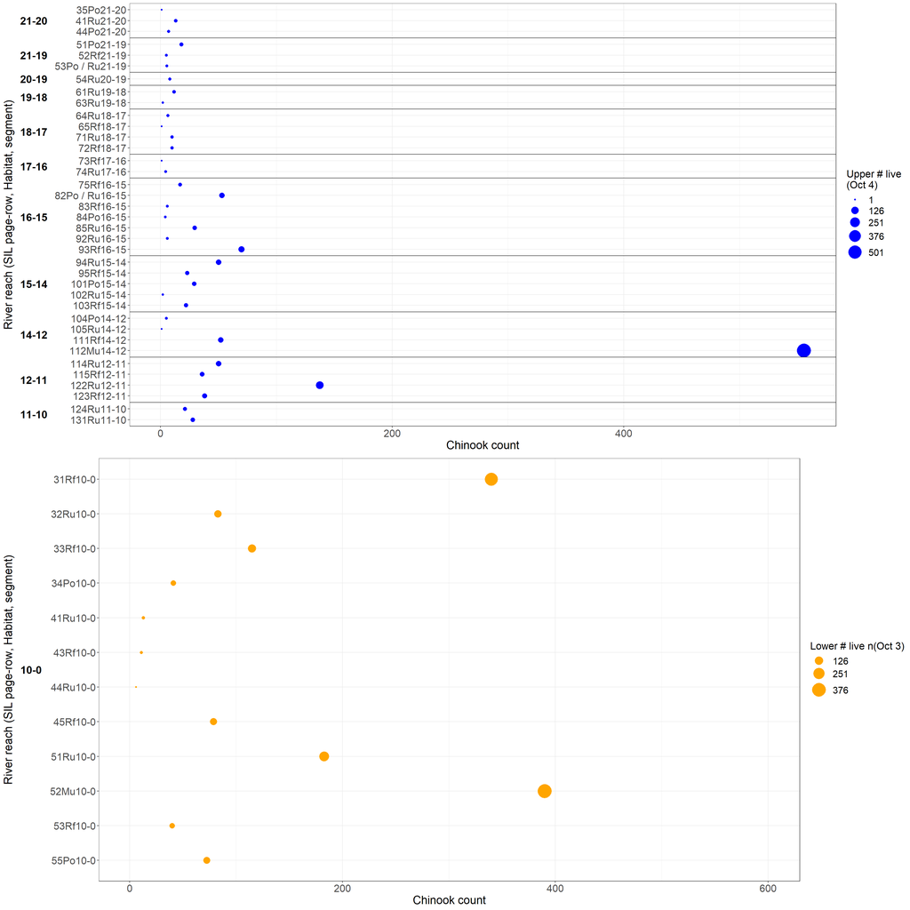

Figure: October 3rd (lower) and 4th (upper) San Juan chinook counts (expanded adults) by segment or SIL row/habitat type. Orientation of y axis represents counts from upstream to downstream reaches.

## 4.6 Tributaries

Table: Chinook counts (raw live and dead) for San Juan tributaries (Renfrew, Lens, Harris) and Gordon River in 2023.

| trib_status | system | date | expanded_live_adults | dead_adults |
| --- | --- | --- | --- | --- |
| Other Area 20 | Gordon | 2023-10-05 | 9 | 0 |
| San Juan trib | Harris | 2023-10-30 | 22 | 0 |
| San Juan trib | Lens | 2023-10-13 | 18 | 0 |
| San Juan trib | Lens | 2023-10-31 | 9 | 0 |
| San Juan trib | Renfrew | 2023-10-16 | 67 | 2 |
| San Juan trib | Renfrew | 2023-11-08 | 0 | 1 |

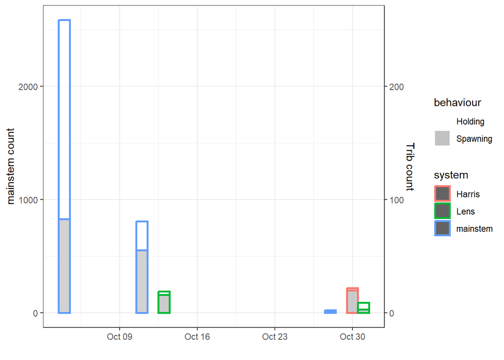

Figure: Mainstem and trib counts for Chinook adults (unexpanded). Indicates subtraction of trib counts from peak mainstem count is likely due to only ~1/3 spawning Oct 3-4. Renfrew excluded as it is a Fairy Lake tributary and downstream of most counts.

## 4.7 Area 20 preliminary escapement estimate (PL+D)

Table: San Juan swim counts (expanded live and dead) and preliminary escapement estimates for three San Juan surveys in 2023.

| ShortSpecies | Section_AreaInspected | SDate | WaterTemperature | WaterClarity | LiveAdults | DeadAdults | LiveJacks | DeadJacks | ExpLiveAdults | ExpDeadAdults | ExpLiveJacks | ExpDeadJacks | OverallReliability | EstPctSeen |
| --- | --- | --- | --- | --- | --- | --- | --- | --- | --- | --- | --- | --- | --- | --- |
| CN | GORDON RIVER | 2023-10-05 | 9.5 | 3 - 5 m or to Bottom | 13 | 0 | 2 | NA | 16 | NA | NA | NA | H | 0.9 |
| CN | HARRIS CREEK | 2023-10-30 | 5.0 | 3 - 5 m or to Bottom | 22 | 0 | 0 | NA | 24 | NA | NA | NA | H | 0.9 |
| CN | LENS CREEK | 2023-10-13 | 9.5 | 3 - 5 m or to Bottom | 19 | 0 | 1 | NA | 19 | NA | NA | NA | H | 1.0 |
| CN | LENS CREEK | 2023-10-31 | 3.0 | 3 - 5 m or to Bottom | 9 | 0 | NA | NA | 10 | NA | NA | NA | H | 0.9 |
| CN | RENFREW CREEK | 2023-10-16 | 10.0 | 3 - 5 m or to Bottom | 67 | 3 | 2 | NA | 74 | NA | NA | NA | H | 0.9 |
| CN | RENFREW CREEK | 2023-11-08 | 7.0 | 3 - 5 m or to Bottom | 0 | 1 | 0 | NA | NA | NA | NA | NA | H | NA |
| CN | SAN JUAN RIVER | 2023-10-03 | 10.0 | 3 - 5 m or to Bottom | 1359 | 28 | 18 | NA | 1374 | NA | NA | NA | H | 1.0 |
| CN | SAN JUAN RIVER | 2023-10-04 | 11.5 | 3 - 5 m or to Bottom | 1228 | 27 | 49 | NA | 1339 | NA | NA | NA | H | 1.0 |
| CN | SAN JUAN RIVER | 2023-10-10 | 9.5 | 3 - 5 m or to Bottom | 129 | 197 | 0 | NA | 129 | NA | NA | NA | H | 1.0 |
| CN | SAN JUAN RIVER | 2023-10-11 | 14.0 | 1 - 3 m | 554 | 99 | 1 | NA | 616 | NA | NA | NA | H | 0.9 |
| CN | SAN JUAN RIVER | 2023-10-12 | 9.5 | 3 - 5 m or to Bottom | 125 | 14 | 2 | NA | 125 | NA | NA | NA | H | 1.0 |
| CN | SAN JUAN RIVER | 2023-10-27 | 6.0 | 3 - 5 m or to Bottom | 21 | 4 | 0 | NA | 21 | NA | NA | NA | H | 1.0 |
| CN | SAN JUAN RIVER | 2023-10-28 | 5.5 | 3 - 5 m or to Bottom | 2 | 8 | NA | NA | 2 | NA | NA | NA | H | 1.0 |
| CN | SAN JUAN RIVER | 2023-10-29 | 5.0 | 3 - 5 m or to Bottom | 0 | 12 | 0 | NA | 0 | NA | NA | NA | H | 1.0 |

Table: Escapement estimates for each system. San Juan mainstem surveys were rolled up based on mid-point date for each of 3 complete survey events, and then the PL+D was selected based on the 3 survey events. **NOTE FINAL SJ CN ESTIMATE DOES NOT YET ACCOUNT FOR REMOVAL OF TRIBUTARY SPAWNERS, THAT MUST BE DONE LATER IN NuSEDS – should be 2642-24-21 = 2597**.

[output not shown]

## 4.8 2023 compared to historical run timing and abundance

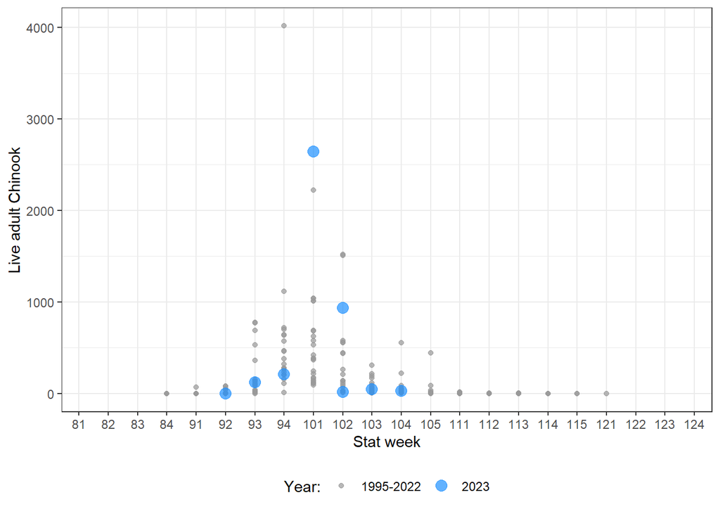

Figure: Raw swim counts (blue) from this year compared to historical raw swim counts. Stat weeks indicate the month (8=August, 12=December) and week of momth (1=first week, 2=2nd week, etc.), e.g., 81=First week of August, 91=First week of September, etc.

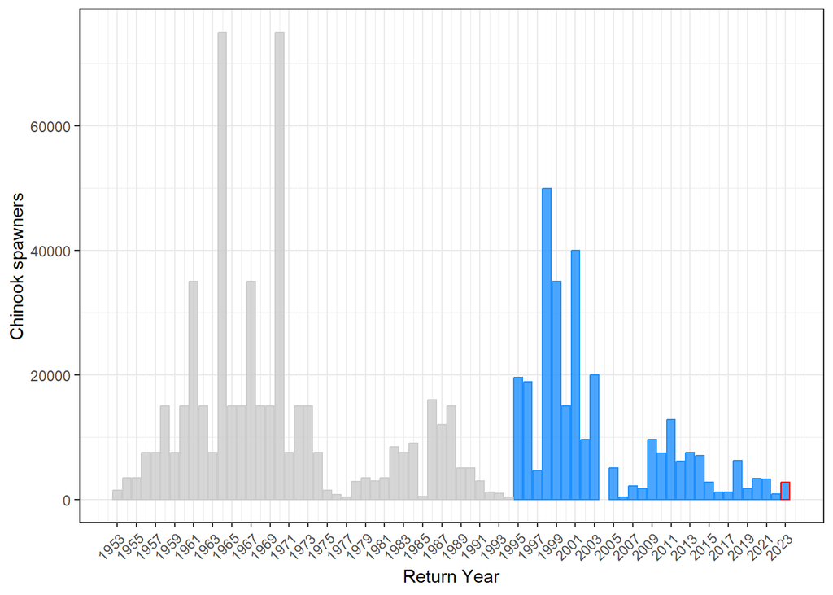

Figure: 2023 preliminary adult Chinook escapement estimate (red outline) relative to historical adult (blue) and unspecified (gray) escapement estimates. Gaps indicate years without estimates.

# 5 **Pink**

No pinks observed in 2023 in any systems.

[output not shown]

[output not shown]